# Harmfull weather events: Impact on the U.S. population health and economy consequences

Andrei Cusnir

2015 May, 23

## Synopsis

Storms and other severe weather events can cause both public health and economic problems for communities and municipalities. Many severe events can result in fatalities, injuries, and property damage, and preventing such outcomes to the extent possible is a key concern.

This project involves exploring the U.S. National Oceanic and Atmospheric Administration’s (NOAA) storm database. This database tracks characteristics of major storms and weather events in the United States, including when and where they occur, as well as estimates of any fatalities, injuries, and property damage.

The basic goal of this analysis is to explore the NOAA Storm Database and answer next **Questions** about severe weather events:

1. Across the United States, which types of events (as indicated in the EVTYPE variable) are most harmful with respect to population health?
2. Across the United States, which types of events have the greatest economic consequences?

The analysis performed in this report shows that most harmfull weather evetns to human population is caused by Tornadoes, Excessive Heat and Floods.  
On the other hand the most economical impact on property is related to Huricane/typhoon, tornadoes, storms.  
The most damage produced to agriculture, crop damage is caused by Droughts, Floods, Ice Storms and Hails.

## Data Processing

### Import libraries that will be used in this script

```r
library(dplyr)
library(grid)
library(ggplot2)
```

### Loading and Processing the Raw Data

```r
data.url <- "https://d396qusza40orc.cloudfront.net/repdata/data/StormData.csv.bz2"
file.name <- "StormData.csv.bz2"

# downloading archive
# for windows users method = "curl" can be skipped
if (!file.exists(file.name)) {
    download.file(data.url, destfile = file.name, method = "curl")
}
```

### Loading the data.

The data is quite big, so it will take some time and resources to load,  
on most modern hardware it should load fine in about 2-3minutes.

```r
# reading the data into storm.data
storm.data <- read.csv(bzfile(file.name))

# make storm.data suitable for usage with dplyr
storm.data <- tbl_df(storm.data)
```

### Inspect 10 most frequent weather event types

```r
select(storm.data, EVTYPE) %>%
    group_by(EVTYPE) %>%
    summarise(count = n()) %>%
    arrange(desc(count))
```

```
## Source: local data frame [985 x 2]
##
##                EVTYPE  count
## 1                HAIL 288661
## 2           TSTM WIND 219940
## 3   THUNDERSTORM WIND  82563
## 4             TORNADO  60652
## 5         FLASH FLOOD  54277
## 6               FLOOD  25326
## 7  THUNDERSTORM WINDS  20843
## 8           HIGH WIND  20212
## 9           LIGHTNING  15754
## 10         HEAVY SNOW  15708
## ..                ...    ...
```

So it can be seen that most frequent harmful weather events are: Hails, thunderstorms, tornadoes, floods, lightnings, heavy snows…

### Number of weather events recorded by year

Though this is not required in the assessment it will be interesting to see how many events where registered each year

```r
# add one column which contains the year of event
storm.data$event.year <- format(as.Date(storm.data$BGN_DATE, "%m/%d/%Y %H:%M:%S"), "%Y")

events.by.year <- select(storm.data, event.year) %>%
    group_by(event.year) %>%
    summarise(count = n())
```

building the plot

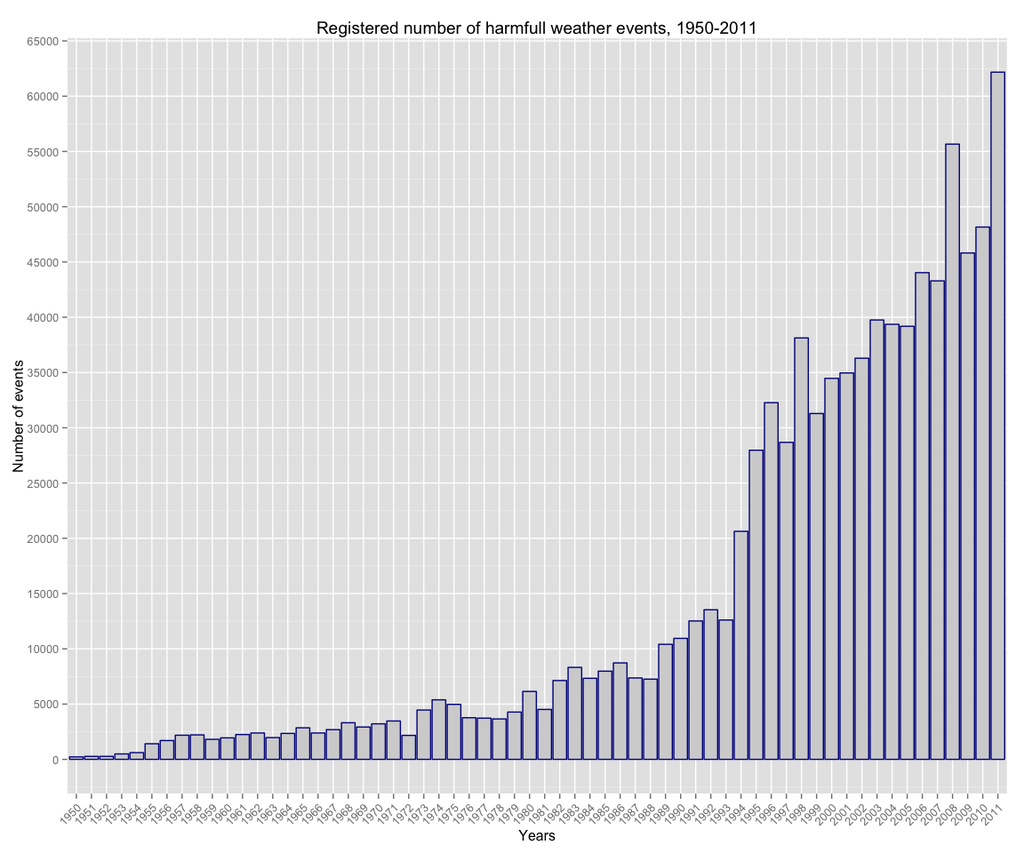

```r
bar0 <- ggplot(events.by.year, aes(event.year, count))
bar0 + geom_bar(stat="identity", colour="darkblue", fill="lightgray") +
    scale_y_continuous(breaks=seq(0, 65000, 5000)) +
    ggtitle("Registered number of harmfull weather events, 1950-2011") +
    ylab("Number of events") + xlab("Years") +
    theme(axis.text.x = element_text(angle = 45, hjust = 1, vjust = 1))
```

The number of registered events was gradually increasing each year since 1950 untill 1993,  
from 1993 the number of registered weather events was increasing at a much faster pace

### Select the variables that will be used in this report

```r
storm.data <- select(storm.data, BGN_DATE, EVTYPE, STATE, COUNTYNAME, FATALITIES, INJURIES,
                     PROPDMG,PROPDMGEXP, CROPDMG, CROPDMGEXP, REFNUM, REMARKS)
```

Make sure selected rows does not have any NA values

```r
anyNA(storm.data)
```

```
## [1] FALSE
```

No NA data in this subset, which is good.

## Results

### 1. Across the United States, which types of events (as indicated in the EVTYPE variable) are most harmful with respect to population health?

```r
population.impact <- select(storm.data, -c(PROPDMG, PROPDMGEXP, CROPDMG, CROPDMGEXP)) %>%
    group_by(EVTYPE) %>%
    summarise(injuries = sum(INJURIES), fatalities = sum(FATALITIES))
population.fatalities <- select(population.impact, EVTYPE, fatalities) %>%
    arrange(desc(fatalities))
population.injuries <- select(population.impact, EVTYPE, injuries) %>%
    arrange(desc(injuries))
```

It is interesting to know what are the “top” 10 states where health is mostly affected by harmfull weather conditions

```r
population.state.impact <- select(storm.data, -c(PROPDMG, PROPDMGEXP, CROPDMG, CROPDMGEXP)) %>%
    group_by(STATE) %>%
    summarise(injuries = sum(INJURIES), fatalities = sum(FATALITIES))
population.state.fatalities <- select(population.state.impact, STATE, fatalities) %>%
    arrange(desc(fatalities)) %>%
    print
```

```
## Source: local data frame [72 x 2]
##
##    STATE fatalities
## 1     IL       1421
## 2     TX       1366
## 3     PA        846
## 4     AL        784
## 5     MO        754
## 6     FL        746
## 7     MS        555
## 8     CA        550
## 9     AR        530
## 10    TN        521
## ..   ...        ...
```

```r
population.state.injuries <- select(population.state.impact, STATE, injuries) %>%
    arrange(desc(injuries)) %>%
    print
```

```
## Source: local data frame [72 x 2]
##
##    STATE injuries
## 1     TX    17667
## 2     MO     8998
## 3     AL     8742
## 4     OH     7112
## 5     MS     6675
## 6     FL     5918
## 7     OK     5710
## 8     IL     5563
## 9     AR     5550
## 10    TN     5202
## ..   ...      ...
```

#### Creating grid plot for top 10 harmfull weather conditions that result in fatalities and injuries.

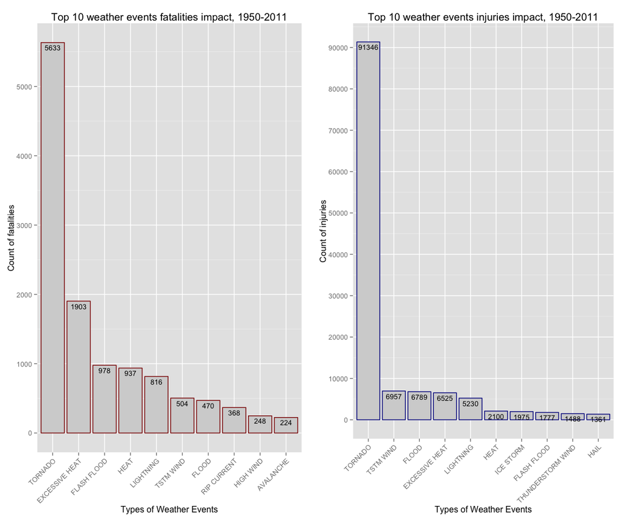

```r
bar1 <- ggplot(population.fatalities[1:10, ], aes(reorder(EVTYPE, -fatalities), fatalities)) +
    geom_bar(stat="identity", colour="darkred", fill="lightgray") +
    scale_y_continuous(breaks=seq(0, 5000, 1000)) +
    ggtitle("Top 10 weather events fatalities impact, 1950-2011") +
    ylab("Count of fatalities") + xlab("Types of Weather Events") +
    geom_text(aes(label = round(fatalities, 0), size = 1, hjust = 0.5, vjust = 1.5)) +
    theme(axis.text.x = element_text(angle = 45, hjust = 1, vjust = 1), legend.position = 'none')

bar2 <- ggplot(population.injuries[1:10, ], aes(reorder(EVTYPE, -injuries), injuries)) +
    geom_bar(stat="identity", colour="darkblue", fill="lightgray") +
    scale_y_continuous(breaks=seq(0, 90000, 10000)) +
    ggtitle("Top 10 weather events injuries impact, 1950-2011") +
    ylab("Count of injuries") + xlab("Types of Weather Events") +
    geom_text(aes(label = round(injuries, 0), size = 1, hjust = 0.5, vjust = 1.5)) +
    theme(axis.text.x = element_text(angle = 45, hjust = 1, vjust = 1), legend.position = 'none')

pushViewport(viewport(layout = grid.layout(1, 2)))
print(bar1, vp = viewport(layout.pos.row = 1, layout.pos.col = 1))
print(bar2, vp = viewport(layout.pos.row = 1, layout.pos.col = 2))
```

So the most harmfull weather event from both tops ten is the Tornado,  
it causes most injuries and fatalities, second most fatal weather condition is Excessive heat, while the second weather condition that causes most injuries is Tstm Wind

### 2. Across the United States, which types of events have the greatest economic consequences?

We have two types of economic impact from harmfull weather conditions:

- Property damages
- Crop damages

Also for some reasons indicated damage is US dollars is split over 2 columns:

- ammount of dollars for either crop or prop
- exp, exponent we should use with the ammount

One thing makes our analyse more difficult is that the exp is presented in different formats.

```r
levels(storm.data$PROPDMGEXP)
```

```
##  [1] ""  "-" "?" "+" "0" "1" "2" "3" "4" "5" "6" "7" "8" "B" "h" "H" "K"
## [18] "m" "M"
```

```r
# and
levels(storm.data$CROPDMGEXP)
```

```
## [1] ""  "?" "0" "2" "B" "k" "K" "m" "M"
```

there seems to be no codebook explaining what -, +, ? however for other symbols we can decode it as follows:

- h,H stands for hundreds, 10^2
- k,K stands for thousands, 10^3
- m,M stands for millions, 10^6
- B stands for billions, 10^9
- a number n that will be exponent 10^n
- for “”, “-”, “+”, “?” will use 10^0=1

Here is calculated the exponent based on this approach for crop and prop damage

```r
propdmg.exp.orig <- c("", "-", "?", "+", "0", "1", "2", "3", "4", "5", "6", "7", "8", "B", "h", "H", "K", "m", "M")
propdmg.exp.new <- c(1, 1, 1, 1, 1, 10, 10^2, 10^3, 10^4, 10^5, 10^6, 10^7, 10^8, 10^9, 10^2, 10^2, 10^3, 10^6, 10^6)
cropdmg.exp.orig <- c("", "?", "0", "2", "B", "k", "K", "m", "M")
cropdmg.exp.new <- c(1, 1, 1, 10^2, 10^9, 10^3, 10^3, 10^6, 10^6)
```

Creating propdmg.multiplyer and cropdmg.multiplyer with numerical multiplyer values

```r
storm.data$propdmg.multiplyer <-
    plyr::mapvalues(storm.data$PROPDMGEXP, propdmg.exp.orig, as.numeric(propdmg.exp.new))
storm.data$propdmg.multiplyer <- as.numeric(as.character(storm.data$propdmg.multiplyer))
storm.data$cropdmg.multiplyer <-
    plyr::mapvalues(storm.data$CROPDMGEXP, cropdmg.exp.orig, as.numeric(cropdmg.exp.new))
storm.data$cropdmg.multiplyer <- as.numeric(as.character(storm.data$cropdmg.multiplyer))
```

Now we can create new variables that will hold full ammount of property and crop damage

```r
storm.data <- mutate(storm.data, prop.dmg = PROPDMG * propdmg.multiplyer) %>%
   mutate(crop.dmg = CROPDMG * cropdmg.multiplyer)
```

Having a look at top 3 weather events with impact on economy

```r
options(dplyr.width = Inf)
top3.crop.impact <- select(storm.data, REFNUM, BGN_DATE, EVTYPE, crop.dmg, STATE, COUNTYNAME) %>%
    arrange(desc(crop.dmg))
head(top3.crop.impact, 3)
```

```
## Source: local data frame [3 x 6]
##
##   REFNUM          BGN_DATE            EVTYPE crop.dmg STATE
## 1 198375 8/31/1993 0:00:00       RIVER FLOOD 5.00e+09    IL
## 2 211887  2/9/1994 0:00:00         ICE STORM 5.00e+09    MS
## 3 581537 8/29/2005 0:00:00 HURRICANE/TYPHOON 1.51e+09    MS
##                       COUNTYNAME
## 1      ADAMS, CALHOUN AND JERSEY
## 2 MSZ001 - 023 - 025 - 026 - 034
## 3 MSZ018>019 - 025>066 - 072>074
```

```r
top3.prop.impact <- select(storm.data, REFNUM, BGN_DATE, EVTYPE, prop.dmg, STATE, COUNTYNAME) %>%
    arrange(desc(prop.dmg))
head(top3.prop.impact, 3)
```

```
## Source: local data frame [3 x 6]
##
##   REFNUM          BGN_DATE            EVTYPE  prop.dmg STATE
## 1 605943  1/1/2006 0:00:00             FLOOD 1.150e+11    CA
## 2 577616 8/29/2005 0:00:00       STORM SURGE 3.130e+10    LA
## 3 577615 8/28/2005 0:00:00 HURRICANE/TYPHOON 1.693e+10    LA
##                         COUNTYNAME
## 1                             NAPA
## 2 LAZ040 - 059 - 061>064 - 067>070
## 3   LAZ034>040 - 046>050 - 056>070
```

Having a look at the particular REFNUM *605943* responsible for the FLOOD in NAPA

```r
filter(storm.data, REFNUM==605943)
```

```
## Source: local data frame [1 x 16]
##
##           BGN_DATE EVTYPE STATE COUNTYNAME FATALITIES INJURIES PROPDMG
## 1 1/1/2006 0:00:00  FLOOD    CA       NAPA          0        0     115
##   PROPDMGEXP CROPDMG CROPDMGEXP REFNUM
## 1          B    32.5          M 605943
##                                                                                                                                                                                                                                                                                                          …
## 1 Major flooding continued into the early hours of January 1st, before the Napa River finally fell below flood stage and the water receeded. Flooding was severe in Downtown Napa from the Napa Creek and the City and Parks Department was hit with $6 million in damage alone. The City of Napa had 600…
##   propdmg.multiplyer cropdmg.multiplyer prop.dmg crop.dmg
## 1              1e+09              1e+06 1.15e+11 32500000
```

Looks like there is an error when submitting property damage, so instead of 115 billions we should have something ore like 115 milions. Also i can see a discussion in the coursera forum about it.

https://class.coursera.org/repdata-014/forum/thread?thread_id=140

So in order to have appropriate results for economic impact i will have to update the calculated value for propdmg for this refnum.

explanation about how next code works (REFNUM==605943) * prop.dmg/1000 + (REFNUM!=605943) * prop.dmg a row can either have refnum==605943 or not so it will either return 0 for first condition or zero for second condition

```r
storm.data <- mutate(storm.data,
                     prop.dmg = (REFNUM==605943) * prop.dmg/1000 + (REFNUM!=605943) * prop.dmg )
```

Next follows mostly the same analysis as for health impact except variables Injuries and Fatalities  
are to be excluded from the storm.data data frame, also grouped_by and summarise will be done on property and crop damage variables

```r
economic.impact <- select(storm.data, -c(FATALITIES, INJURIES)) %>%
    group_by(EVTYPE) %>%
    summarise(crop.dmg = sum(crop.dmg), prop.dmg = sum(prop.dmg))
prop.damage <- select(economic.impact, EVTYPE, prop.dmg) %>%
    arrange(desc(prop.dmg))
crop.damage <- select(economic.impact, EVTYPE, crop.dmg) %>%
    arrange(desc(crop.dmg))
```

Looking at top 10 states mostly affected economicaly by harmfull weather conditions.

```r
economic.state.impact <- select(storm.data, -c(FATALITIES, INJURIES)) %>%
    group_by(STATE) %>%
    summarise(crop.dmg = round(sum(crop.dmg)/10^9, 2), prop.dmg = round(sum(prop.dmg)/10^9, 2))
```

Economic damage indicated in Billions

```r
prop.state.damage <- select(economic.state.impact, STATE, prop.dmg) %>%
    arrange(desc(prop.dmg)) %>%
    print
```

```
## Source: local data frame [72 x 2]
##
##    STATE prop.dmg
## 1     LA    60.07
## 2     FL    41.51
## 3     MS    29.81
## 4     TX    26.64
## 5     AL    17.24
## 6     NC     8.91
## 7     CA     8.70
## 8     IL     8.62
## 9     MO     7.32
## 10    OH     6.86
## ..   ...      ...
```

```r
crop.state.damage <- select(economic.state.impact, STATE, crop.dmg) %>%
    arrange(desc(crop.dmg)) %>%
    print
```

```
## Source: local data frame [72 x 2]
##
##    STATE crop.dmg
## 1     TX     7.30
## 2     MS     6.61
## 3     IL     5.55
## 4     IA     4.70
## 5     FL     3.90
## 6     CA     3.53
## 7     NE     2.17
## 8     NC     2.05
## 9     LA     1.23
## 10    OK     1.21
## ..   ...      ...
```

LA, FL, MS, TX and AL are top 5 states that harmful weather causes most of property damages.  
TX, MS, IL, IA and FL are top 5 states that harmful weather causes most of crop damages.

#### Building the grid plot with harmfull weather conditions impact on economy stats

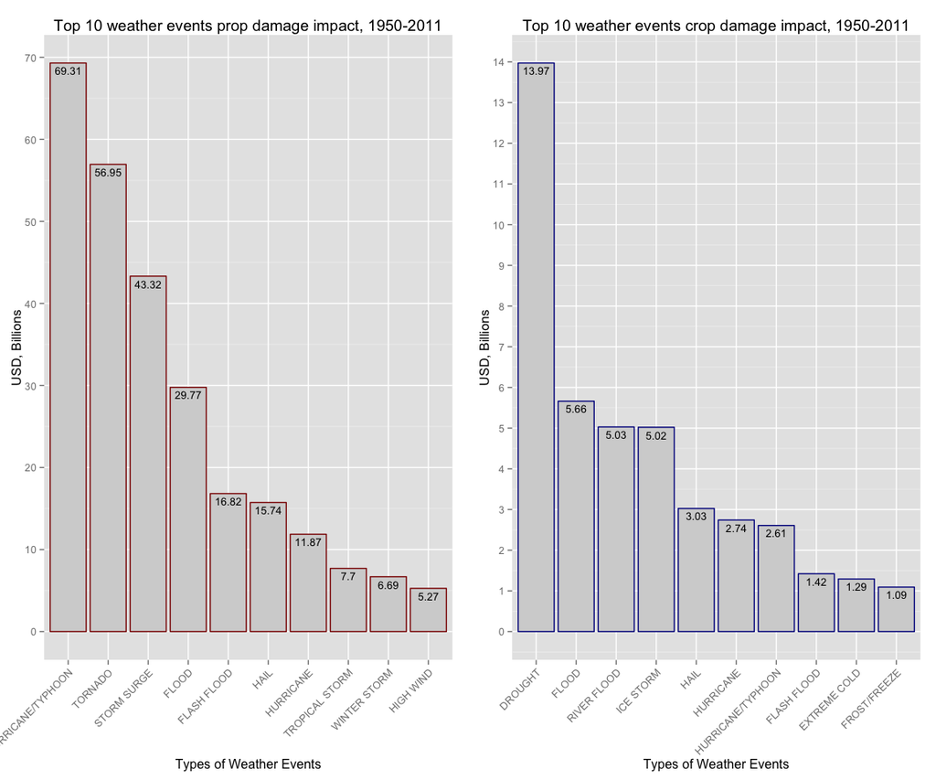

```r
bar3 <- ggplot(prop.damage[1:10, ], aes(reorder(EVTYPE, -prop.dmg), prop.dmg/10^9)) +
    geom_bar(stat="identity", colour="darkred", fill="lightgray") +
    scale_y_continuous(breaks=seq(0, 140, 10)) +
    ggtitle("Top 10 weather events prop damage impact, 1950-2011") +
    ylab("USD, Billions") + xlab("Types of Weather Events") +
    geom_text(aes(label = round(prop.dmg/10^9, 2), size = 1, hjust = 0.5, vjust = 1.5)) +
    theme(axis.text.x = element_text(angle = 45, hjust = 1, vjust = 1), legend.position = 'none')

bar4 <- ggplot(crop.damage[1:10, ], aes(reorder(EVTYPE, -crop.dmg), crop.dmg/10^9)) +
    geom_bar(stat="identity", colour="darkblue", fill="lightgray") +
    scale_y_continuous(breaks=seq(0, 15, 1)) +
    ggtitle("Top 10 weather events crop damage impact, 1950-2011") +
    ylab("USD, Billions") + xlab("Types of Weather Events") +
    geom_text(aes(label = round(crop.dmg/10^9, 2), size = 1, hjust = 0.5, vjust = 1.5)) +
    theme(axis.text.x = element_text(angle = 45, hjust = 1, vjust = 1), legend.position = 'none')

pushViewport(viewport(layout = grid.layout(1, 2)))
print(bar3, vp = viewport(layout.pos.row = 1, layout.pos.col = 1))
print(bar4, vp = viewport(layout.pos.row = 1, layout.pos.col = 2))
```

So it can be clearly seen that most impact from harmful weather on agriculture(crops) is due to Droughts and Floods while most of property damages are due to Huricane/Typhoon, Tornadoes ans Storms.